# Reproducible Research: Peer Assessment 1

Olga Hartoog

20-10-2017

## Loading and preprocessing the data

```r
activity <- read.csv("activity.csv")

activity$date <- as.Date(activity$date)
```

## What is mean total number of steps taken per day?

Load the libraries for the assignment

```r
library(dplyr)
library(lattice)
```

Calculate and show the total number of steps per day

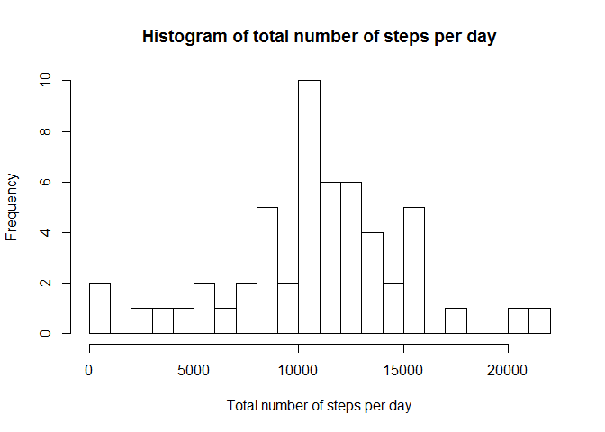

```r
activity_daily <- activity %>% group_by(date) %>% summarise(totalsteps = sum(steps))
hist(activity_daily$totalsteps,
     breaks = 30,
     main = "Histogram of total number of steps per day",
     xlab = "Total number of steps per day"
     )
```

Calulate the median and mean of the total number of steps per day.

```r
median(activity_daily$totalsteps,na.rm = TRUE)
```

```
## [1] 10765
```

```r
mean(activity_daily$totalsteps,na.rm = TRUE)
```

```
## [1] 10766.19
```

## What is the average daily activity pattern?

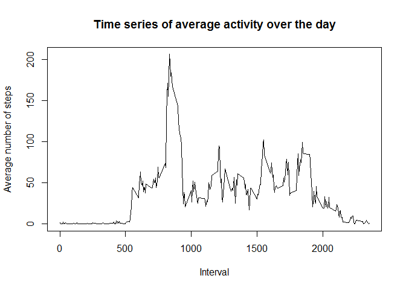

```r
activity_avgday <- activity %>% group_by(interval) %>% summarise(meansteps = mean(steps,na.rm = TRUE))
plot(activity_avgday$interval,
     activity_avgday$meansteps,
     type = "l",
     xlab = "Interval",
     ylab = "Average number of steps",
     main = "Time series of average activity over the day"
     )
```

The interval with the highest average number of steps:

```r
activity_avgday[which.max(activity_avgday$meansteps),]
```

```
## # A tibble: 1 x 2
##   interval meansteps
##      <int>     <dbl>
## 1      835  206.1698
```

The interval with the maximum average number of steps is 835.

## Imputing missing values

Total number of missing values in the data:

```r
sum(is.na(activity$steps))
```

```
## [1] 2304
```

Imputing the missing values with the mean number of steps of the interval:

```r
activity_imputed <- merge(activity,activity_avgday)

activity_imputed$steps <- ifelse(is.na(activity_imputed$steps),
                                  activity_imputed$meansteps,
                                  activity_imputed$steps)

activity_imputed$meansteps <- NULL
```

Show the histogram for the imputed dataset:

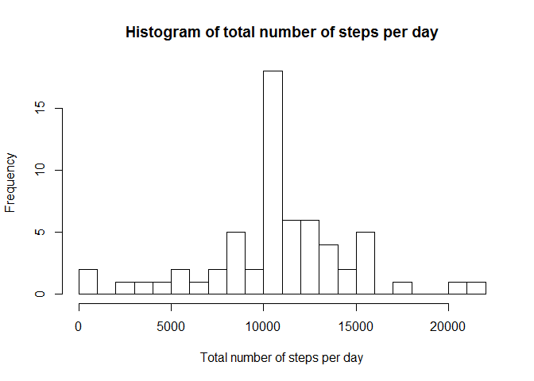

```r
activity_imputed_daily <- activity_imputed %>% group_by(date) %>% summarise(totalsteps = sum(steps))

hist(activity_imputed_daily$totalsteps,
     breaks = 30,
     main = "Histogram of total number of steps per day",
     xlab = "Total number of steps per day"
     )
```

Calulate the median and mean of the total number of steps per day on the imputed file.

```r
median(activity_imputed_daily$totalsteps,na.rm = TRUE)
```

```
## [1] 10766.19
```

```r
mean(activity_imputed_daily$totalsteps,na.rm = TRUE)
```

```
## [1] 10766.19
```

## Are there differences in activity patterns between weekdays and weekends?

Create a new factor variable indicating if the date is a weekday or a weekend day

```r
activity_imputed$weekend <-
            as.factor(
              ifelse(weekdays(activity_imputed$date) %in% c("zaterdag","zondag"),
                     "weekend",
                     "weekday"
                     )
              )
```

Show the difference in the daily pattern for weekdays and weekend days:

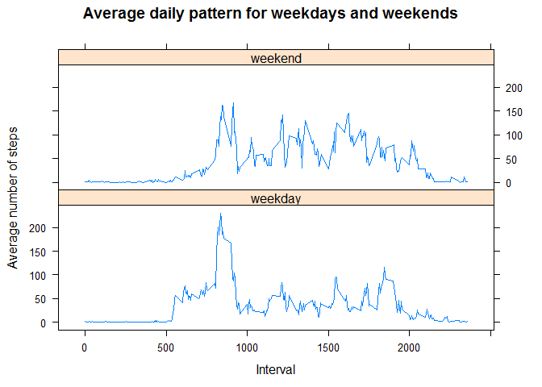

```r
activity_imputed_avgday <- activity_imputed %>% group_by(interval,weekend) %>% summarise(meansteps = mean(steps,na.rm = TRUE))

xyplot(activity_imputed_avgday$meansteps~activity_imputed_avgday$interval|activity_imputed_avgday$weekend,
       type = 'l',
       main = "Average daily pattern for weekdays and weekends",
       xlab = "Interval",
       ylab = "Average number of steps",
       layout = c(1,2)
       )
```